# Sentiment Analysis

Let me first read in a common dataset for all our sentiment-an examples.

```r
# IBM Q3 2016 analyst call transcript
x = readLines('https://raw.githubusercontent.com/sudhir-voleti/sample-data-sets/master/International%20Business%20Machines%20(IBM)%20Q3%202016%20Results%20-%20Earnings%20Call%20Transcript.txt')
```

### Using qdap for sentiment analysis

qdap or the qualitative discourse analysis package offers a relatively rigorous sentiment-An approach. However, it is limited to a standard dictionary (from Princeton).

Our main use of sentiment-An in this session shall be with tidytext library. However, for completeness sake, let’s quickly do qdap first.

```r
# loading required libraries
require(qdap) || install.packages("qdap") # ensure java is up to date!
library(qdap)
```

```r
require(qdap)
```

Use `polarity()` func from qdap and store its output into various variables. Try `?qdap::polarity` for more detail.

```r
# apply polarity() func from qdap to compute sentiment polarity
t1 = Sys.time()   # set timer
  pol = qdap::polarity(x)         # Calculate the polarity from qdap dictionary
  wc = pol$all[,2]                  # Word Count in each doc
  val = pol$all[,3]                 # average polarity score
  p  = pol$all[,4]                  # Positive words info
  n  = pol$all[,5]                  # Negative Words info
Sys.time() - t1  # how much time did the above take?
```

```
## Time difference of 2.24 secs
```

View output variables.

```r
head(pol$all)
```

```
##   all wc   polarity pos.words neg.words
## 1 all  6  0.0000000         -         -
## 2 all  5  0.0000000         -         -
## 3 all  3  0.0000000         -         -
## 4 all  1  0.0000000         -         -
## 5 all  6 -0.4082483         -      vice
## 6 all  9 -0.3333333         -      vice
##                                                               text.var
## 1              International Business Machines Corporation. (NYSE:IBM)
## 2                             Q3 2016 Results Earnings Conference Call
## 3                                        October 17, 2016, 05:00 PM ET
## 4                                                           Executives
## 5                  Patricia Murphy - Vice President-Investor Relations
## 6 Martin Schroeter - Senior Vice President and Chief Financial Officer
```

Summarize polarity scores for the corpus

```r
head(pol$group)
```

```
##   all total.sentences total.words ave.polarity sd.polarity
## 1 all             219       10275    0.1032166   0.2454903
##   stan.mean.polarity
## 1          0.4204508
```

What positive words were there in the corpus?

```r
positive_words = unique(setdiff(unlist(p),"-"))  # Positive words list, do ?dplyr::setdiff
print(positive_words)       # Print all the positive words found in the corpus
```

```
##  [1] "thank"           "like"            "welcome"
##  [4] "available"       "reform"          "reconciliation"
##  [7] "stability"       "strong"          "top"
## [10] "consistent"      "led"             "solid"
## [13] "modest"          "good"            "progress"
## [16] "best"            "well"            "innovation"
## [19] "success"         "helping"         "leverage"
## [22] "contribution"    "easy"            "intelligence"
## [25] "better"          "trusted"         "support"
## [28] "smart"           "work"            "improvements"
## [31] "improved"        "gains"           "meaningful"
## [34] "effective"       "benefit"         "free"
## [37] "improvement"     "gain"            "capability"
## [40] "correct"         "wins"            "improve"
## [43] "compliant"       "efficient"       "trusting"
```

[output cut: 16 more lines]

We can use the wordlcoud or barchart or other display aids as required on the list above.

What negative words were there in the corpus?

```r
negative_words = unique(setdiff(unlist(n),"-"))  # Negative words list
print(negative_words)       # Print all neg words
```

```
##  [1] "vice"          "volatility"    "cloud"         "decline"
##  [5] "drones"        "critical"      "risk"          "cancer"
##  [9] "uncertain"     "weaker"        "gross"         "set up"
## [13] "chronic"       "risks"         "latency"       "object"
## [17] "declining"     "drag"          "debt"          "declines"
## [21] "oppose"        "bump"          "negative"      "indiscernible"
## [25] "volatile"      "errors"        "inaccuracies"
```

While qdap is nice and easy, its limitations are also there.

E.g., it uses an inbuilt wordlist that cannot be customized for particular contexts.

Another is that it does exact matching and misses minor variations in sentiment words. It suffers from the old problems of *synonymy* (i.e., multiple words that have similar meanings) and *polysemy* (words that have more than one meaning).

While these are old standing problems and cannot be eliminated in the bag of words approach, more flexibility would enable a substantial mitigation at least.

### Sentiment-An with Tidytext

There are 3 inbuilt sentiment dictionaries as of now in tidytext with a fourth under development.

To briefly see what these are, return to the slides.

The nice thing about tidytext is that while there are 3 inbuilt sentiment dictionaires in different output formats for convenience, we can also create and customize our own wordlists as needed.

```r
require(tidytext)
require(tidyr)
require(dplyr)
```

The tidytext package contains all three sentiment lexicons in the sentiments dataset.

```r
sentiments    # over 27k words sentiment-ized and scored across the 3 lexicons
```

```
## # A tibble: 27,314 × 4
##           word sentiment lexicon score
##          <chr>     <chr>   <chr> <int>
## 1       abacus     trust     nrc    NA
## 2      abandon      fear     nrc    NA
## 3      abandon  negative     nrc    NA
## 4      abandon   sadness     nrc    NA
## 5    abandoned     anger     nrc    NA
## 6    abandoned      fear     nrc    NA
## 7    abandoned  negative     nrc    NA
## 8    abandoned   sadness     nrc    NA
## 9  abandonment     anger     nrc    NA
## 10 abandonment      fear     nrc    NA
## # ... with 27,304 more rows
```

```r
sentiments %>%
          filter(lexicon == "AFINN") %>%
          head()
```

```
## # A tibble: 6 × 4
##         word sentiment lexicon score
##        <chr>     <chr>   <chr> <int>
## 1    abandon      <NA>   AFINN    -2
## 2  abandoned      <NA>   AFINN    -2
## 3   abandons      <NA>   AFINN    -2
## 4   abducted      <NA>   AFINN    -2
## 5  abduction      <NA>   AFINN    -2
## 6 abductions      <NA>   AFINN    -2
```

Let’s start simple, with Bing.

```r
textdf = data_frame(text = x)   # convert to data frame

bing = get_sentiments("bing")   # put all of the bing sentiment dict into object 'bing'
bing     # view bing object
```

```
## # A tibble: 6,788 × 2
##           word sentiment
##          <chr>     <chr>
## 1      2-faced  negative
## 2      2-faces  negative
## 3           a+  positive
## 4     abnormal  negative
## 5      abolish  negative
## 6   abominable  negative
## 7   abominably  negative
## 8    abominate  negative
## 9  abomination  negative
## 10       abort  negative
## # ... with 6,778 more rows
```

Which docs are most positive and negative in the corpus?

```r
senti.bing = textdf %>%
      mutate(linenumber = row_number()) %>%   # build line num variable
      ungroup() %>%
      unnest_tokens(word, text) %>%
      inner_join(get_sentiments("bing")) %>%
      count(sentiment, index = linenumber %/% 1, sort = FALSE) %>%
      mutate(method = "bing")    # creates a column with method name
senti.bing
```

```
## Source: local data frame [186 x 4]
## Groups: sentiment [2]
##
##    sentiment index     n method
##        <chr> <dbl> <int>  <chr>
## 1   negative     5     1   bing
## 2   negative     6     1   bing
## 3   negative    19     2   bing
## 4   negative    25     1   bing
## 5   negative    26     2   bing
## 6   negative    27     1   bing
## 7   negative    28     3   bing
## 8   negative    29     1   bing
## 9   negative    31     1   bing
## 10  negative    32     1   bing
## # ... with 176 more rows
```

Now let’s see the distribution of positive and negative sentiment within documents across the corpus.

Note use of the `spread()` function to combine extra row pertaining to some index (doc) and make an extra column. Do `?tidyr::spread` for more info.

```r
bing_df = data.frame(senti.bing %>% spread(sentiment, n, fill = 0))

head(bing_df)
```

```
##   index method negative positive
## 1     5   bing        1        0
## 2     6   bing        1        0
## 3    19   bing        2        3
## 4    20   bing        0        1
## 5    21   bing        0        2
## 6    22   bing        0        1
```

Can we combine the negative and positive rows, by say, subtracting negative from poisitive score and thereby computing some polarity score for each line? Yes, see code below.

```r
bing_pol = bing_df %>%
  mutate(polarity = (positive - negative)) %>%   #create variable polarity = pos - neg
  arrange(desc(polarity), index)    # sort by polarity

bing_pol %>%  head()
```

```
##   index method negative positive polarity
## 1   212   bing        0        9        9
## 2   110   bing        0        8        8
## 3   154   bing        1        9        8
## 4   160   bing        0        8        8
## 5   129   bing        1        7        6
## 6    45   bing        0        5        5
```

Now for some quick visualization of the distribution of sentiment across the analyst call. See code below.

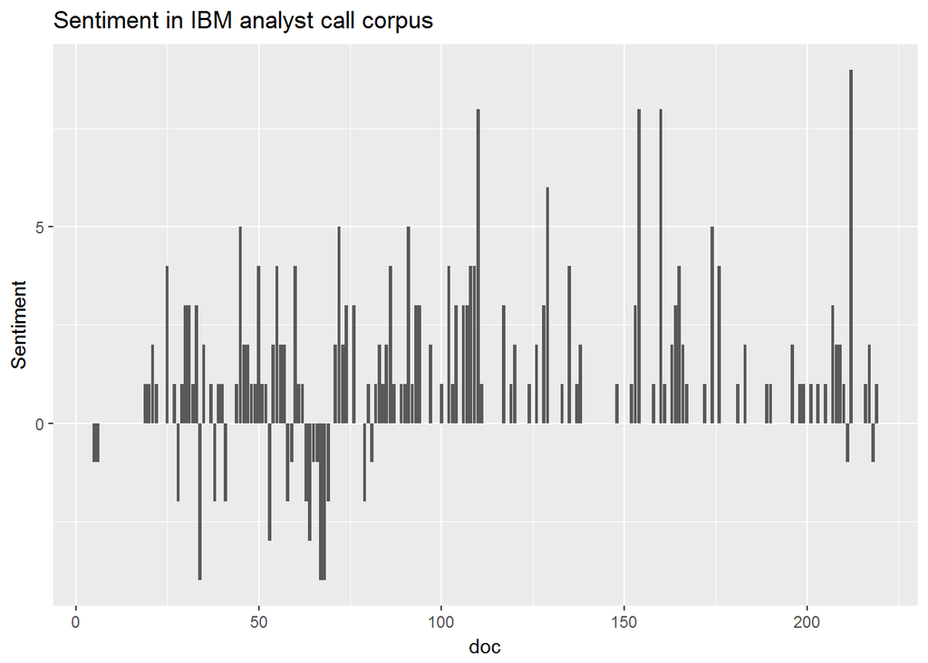

```r
require(ggplot2)
# plotting running sentiment distribution across the analyst call
ggplot(bing_pol,
       aes(index, polarity)) +
       geom_bar(stat = "identity", show.legend = FALSE) +
      labs(title = "Sentiment in IBM analyst call corpus",
             x = "doc",
             y = "Sentiment")
```

Another quick visualization. We want to see which words contributed most to positive or neg sentiment in the corpus using the bing lexicon.

So first we create a count of bing sentiment words that occur a lot in the corpus.

```r
bing_word_counts <- textdf %>%
                    unnest_tokens(word, text) %>%
                    inner_join(bing) %>%
                    count(word, sentiment, sort = TRUE) %>%
                    ungroup()
bing_word_counts
```

```
## # A tibble: 118 × 3
##         word sentiment     n
##        <chr>     <chr> <int>
## 1      cloud  negative    60
## 2      thank  positive    22
## 3       good  positive    21
## 4       well  positive    19
## 5       free  positive    17
## 6       like  positive    14
## 7     strong  positive    12
## 8      right  positive    11
## 9      gross  negative     8
## 10 important  positive     8
## # ... with 108 more rows
```

Now `ggplot` it and see.

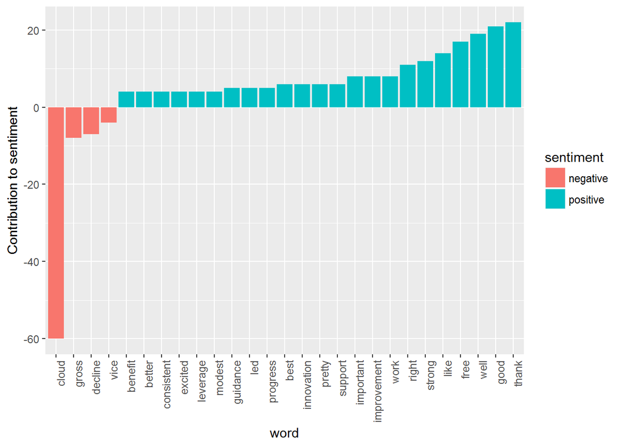

```r
bing_word_counts %>%
  filter(n > 3) %>%
  mutate(n = ifelse(sentiment == "negative", -n, n)) %>%
  mutate(word = reorder(word, n)) %>%
  ggplot(aes(word, n, fill = sentiment)) +
  geom_bar(stat = "identity") +
  theme(axis.text.x = element_text(angle = 90, hjust = 1)) +
  ylab("Contribution to sentiment")
```

And then there’re wordclouds.

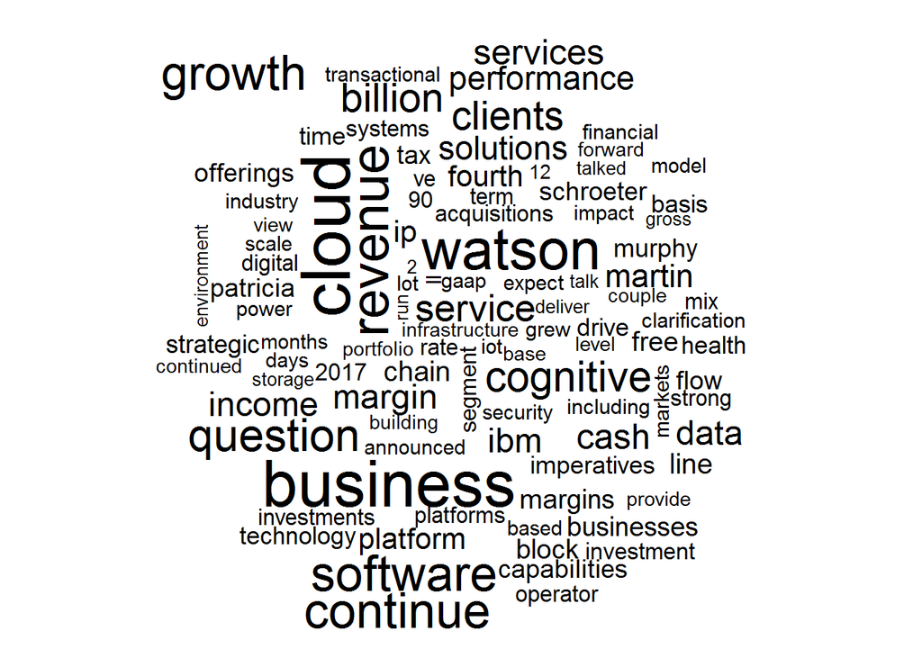

```r
require(wordcloud)
# build wordcloud of commonest tokens
textdf %>%
  unnest_tokens(word, text) %>%
  anti_join(stop_words) %>%
  count(word) %>%
  with(wordcloud(word, n, max.words = 100))
```

### Sentiment-An with AFINN

```r
# get AFINN first
AFINN <- get_sentiments("afinn")
AFINN
```

```
## # A tibble: 2,476 × 2
##          word score
##         <chr> <int>
## 1     abandon    -2
## 2   abandoned    -2
## 3    abandons    -2
## 4    abducted    -2
## 5   abduction    -2
## 6  abductions    -2
## 7       abhor    -3
## 8    abhorred    -3
## 9   abhorrent    -3
## 10     abhors    -3
## # ... with 2,466 more rows
```

```r
# inner join AFINN words and scores with text tokens from corpus
senti.afinn = textdf %>%
      mutate(linenumber = row_number()) %>%
      ungroup() %>%
      unnest_tokens(word, text) %>%
      inner_join(AFINN) %>%    # returns only intersection of wordlists and all columns
      group_by(index = linenumber %/% 1) %>%
      summarise(sentiment = sum(score)) %>%
      mutate(method = "afinn")
senti.afinn
```

```
## # A tibble: 140 × 3
##    index sentiment method
##    <dbl>     <int>  <chr>
## 1     19         6  afinn
## 2     20         1  afinn
## 3     21         0  afinn
## 4     22         1  afinn
## 5     25        11  afinn
## 6     26         7  afinn
## 7     27         6  afinn
## 8     28        14  afinn
## 9     29         9  afinn
## 10    30         6  afinn
## # ... with 130 more rows
```

```r
data.frame(senti.afinn) %>% head()
```

```
##   index sentiment method
## 1    19         6  afinn
## 2    20         1  afinn
## 3    21         0  afinn
## 4    22         1  afinn
## 5    25        11  afinn
## 6    26         7  afinn
```

Can we combine sentiment-An with bigrams?

E.g., Suppose you want to list bigrams where first word is a sentiment word. See code below.

```r
# first construct and split bigrams into word1 and word2
ibm_bigrams_separated <- textdf %>%
                unnest_tokens(bigram, text,
                token = "ngrams", n = 2) %>%
                separate(bigram, c("word1", "word2"), sep = " ")

ibm_bigrams_separated
```

```
## # A tibble: 10,417 × 2
##            word1       word2
## *          <chr>       <chr>
## 1  international    business
## 2       business    machines
## 3       machines corporation
## 4    corporation    nyse:ibm
## 5       nyse:ibm          q3
## 6             q3        2016
## 7           2016     results
## 8        results    earnings
## 9       earnings  conference
## 10    conference        call
## # ... with 10,407 more rows
```

Next, inner join with AFINN

```r
# examine the most frequent bigrams whose first word is a sentiment word
senti_bigrams <- ibm_bigrams_separated %>%
              inner_join(AFINN, by = c(word1 = "word")) %>%     # word1 is from bigrams and word from AFINN
              ungroup()
senti_bigrams
```

```
## # A tibble: 474 × 3
##         word1    word2 score
##         <chr>    <chr> <int>
## 1       thank      you     2
## 2        like       to     2
## 3     welcome      you     2
## 4    prepared  remarks     1
## 5     certain comments     1
## 6  litigation   reform    -1
## 7     certain      non     1
## 8      thanks patricia     2
## 9       share       as     1
## 10       like  banking     2
## # ... with 464 more rows
```

Filter out stopwords and then do inner join with AFINN.

```r
# what if we want sentiment associated with proper words, not stopwords?
senti_bigrams_filtered = ibm_bigrams_separated %>%
                        filter(!word1 %in% stop_words$word) %>%
                        filter(!word2 %in% stop_words$word) %>%
                        inner_join(AFINN, by = c(word1 = "word")) %>%     # word1 is from bigrams and word from AFINN
                        ungroup()

senti_bigrams_filtered
```

```
## # A tibble: 135 × 3
##         word1       word2 score
##         <chr>       <chr> <int>
## 1    prepared     remarks     1
## 2  litigation      reform    -1
## 3      strong      growth     2
## 4      strong      growth     2
## 5       solid   recurring     2
## 6    solution    software     1
## 7      strong performance     2
## 8      strong     revenue     2
## 9      strong      growth     2
## 10       easy      hybrid     1
## # ... with 125 more rows
```

And so on.

Heading finally to the NRC dictionary.

### Sentiment-An with the NRC dictionary

```r
# view nrc dict structure
nrc = get_sentiments("nrc")
nrc
```

```
## # A tibble: 13,901 × 2
##           word sentiment
##          <chr>     <chr>
## 1       abacus     trust
## 2      abandon      fear
## 3      abandon  negative
## 4      abandon   sadness
## 5    abandoned     anger
## 6    abandoned      fear
## 7    abandoned  negative
## 8    abandoned   sadness
## 9  abandonment     anger
## 10 abandonment      fear
## # ... with 13,891 more rows
```

```r
#
senti.nrc = textdf %>%
      mutate(linenumber = row_number()) %>%
      ungroup() %>%
      unnest_tokens(word, text) %>%
      inner_join(get_sentiments("nrc")) %>%
      count(sentiment, index = linenumber %/% 1, sort = FALSE) %>%  # %/% gives quotient
      mutate(method = "nrc")
senti.nrc %>% head()
```

```
## Source: local data frame [6 x 4]
## Groups: sentiment [1]
##
##   sentiment index     n method
##       <chr> <dbl> <int>  <chr>
## 1     anger    13     1    nrc
## 2     anger    25     1    nrc
## 3     anger    31     1    nrc
## 4     anger    38     1    nrc
## 5     anger    40     1    nrc
## 6     anger    42     1    nrc
```

```r
# make a neat table out of the 8 emotion dimensions
a = data.frame(senti.nrc %>% spread(sentiment, n, fill = 0))
head(a)
```

```
##   index method anger anticipation disgust fear joy negative positive
## 1     1    nrc     0            0       0    0   0        0        1
## 2     5    nrc     0            0       0    0   0        1        1
## 3     6    nrc     0            0       0    0   0        1        2
## 4    13    nrc     1            0       1    1   0        1        0
## 5    19    nrc     0            0       0    0   0        2        3
## 6    20    nrc     0            3       0    0   0        0        1
##   sadness surprise trust
## 1       0        0     1
## 2       0        0     1
## 3       0        0     2
## 4       1        0     1
## 5       0        0     3
## 6       0        0     1
```

Suppose you want to see what joyful words most occurred in the corpus.

```r
ibm_joy = textdf %>%
      unnest_tokens(word, text) %>%
      inner_join(nrc) %>%
      filter(sentiment == "joy") %>%
      count(word, sort = TRUE)
ibm_joy %>% head()
```

```
## # A tibble: 6 × 2
##          word     n
##         <chr> <int>
## 1        cash    25
## 2      income    24
## 3        good    21
## 4        kind    10
## 5 improvement     8
## 6        grow     7
```